# Capstone Milestone

Drew Triplett

May 2, 2018

# Introduction

This Milestone Report is about exploratory data analysis of the Capstone Project of the Data Science Coursera specialization. Coursera and SwitfKey are partnering on this project; that apply data science in the area of natural language. The project uses a large text corpus of documents to predict the next word on preceding input. The data is extracted and cleaned from files and used with the Shiny application. Here, we have some information about the corpus of data and prepare a plan to create the predictive model.

# Getting the Data

The data is from HC Corpora with access to 4 languages, but only English will be used. The dataset has three files.

```
- en_US.blogs.txt

- en_US.news.txt

- en_US.twitter.txt.
```

The data was loaded from Coursera Link to local machine and will be read from local disk.

```r
# specify the source and destination of the download
destination_file <- "Coursera-SwiftKey.zip"
source_file <- "http://d396qusza40orc.cloudfront.net/dsscapstone/dataset/Coursera-SwiftKey.zip"

# execute the download
download.file(source_file, destination_file)

# extract the files from the zip file
unzip(destination_file)
#Inspect the unzipped files

# find out which files where unzipped
unzip(destination_file, list = TRUE )
```

```
##                             Name    Length                Date
## 1                         final/         0 2014-07-22 10:10:00
## 2                   final/de_DE/         0 2014-07-22 10:10:00
## 3  final/de_DE/de_DE.twitter.txt  75578341 2014-07-22 10:11:00
## 4    final/de_DE/de_DE.blogs.txt  85459666 2014-07-22 10:11:00
## 5     final/de_DE/de_DE.news.txt  95591959 2014-07-22 10:11:00
## 6                   final/ru_RU/         0 2014-07-22 10:10:00
## 7    final/ru_RU/ru_RU.blogs.txt 116855835 2014-07-22 10:12:00
## 8     final/ru_RU/ru_RU.news.txt 118996424 2014-07-22 10:12:00
## 9  final/ru_RU/ru_RU.twitter.txt 105182346 2014-07-22 10:12:00
## 10                  final/en_US/         0 2014-07-22 10:10:00
## 11 final/en_US/en_US.twitter.txt 167105338 2014-07-22 10:12:00
## 12    final/en_US/en_US.news.txt 205811889 2014-07-22 10:13:00
## 13   final/en_US/en_US.blogs.txt 210160014 2014-07-22 10:13:00
## 14                  final/fi_FI/         0 2014-07-22 10:10:00
## 15    final/fi_FI/fi_FI.news.txt  94234350 2014-07-22 10:11:00
## 16   final/fi_FI/fi_FI.blogs.txt 108503595 2014-07-22 10:12:00
## 17 final/fi_FI/fi_FI.twitter.txt  25331142 2014-07-22 10:10:00
```

```r
# inspect the data
list.files("final")
```

```
## [1] "de_DE" "en_US" "fi_FI" "ru_RU"
```

```r
list.files("final/en_US")
```

```
## [1] "en_US.blogs.txt"   "en_US.news.txt"    "en_US.twitter.txt"
```

```r
# import the blogs and twitter datasets in text mode
blogs <- readLines("final/en_US/en_US.blogs.txt", encoding="UTF-8")
twitter <- readLines("final/en_US/en_US.twitter.txt", encoding="UTF-8")
# import the news dataset in binary mode
con <- file("final/en_US/en_US.news.txt", open="rb")
news <- readLines(con, encoding="UTF-8")
close(con)
rm(con)
```

# Basic Statistics

```r
# file size (in MegaBytes/MB)
file.info("final/en_US/en_US.blogs.txt")$size   / 1024^2
```

```
## [1] 200.4242
```

```r
file.info("final/en_US/en_US.news.txt")$size    / 1024^2
```

```
## [1] 196.2775
```

```r
file.info("final/en_US/en_US.twitter.txt")$size / 1024^2
```

```
## [1] 159.3641
```

```r
# our analysis we need two libraries.

#We analyse the lines and characters.
stri_stats_general(blogs)
```

[output not shown]

```
##       Lines LinesNEmpty       Chars CharsNWhite
##      899288      899288   206824382   170389539
```

```r
stri_stats_general(news)
```

```
##       Lines LinesNEmpty       Chars CharsNWhite
##     1010242     1010242   203223154   169860866
```

```r
stri_stats_general(twitter)
```

```
##       Lines LinesNEmpty       Chars CharsNWhite
##     2360148     2360148   162096031   134082634
```

# Sample the Data

```r
set.seed(1012)
sTwitter <- sample(twitter, size = 5000, replace = TRUE)
sBlogs <- sample(blogs, size = 5000, replace = TRUE)
sNews <- sample(news, size = 5000, replace = TRUE)
sampleTotal <- c(sTwitter, sBlogs, sNews)
length(sampleTotal)
```

```
## [1] 15000
```

```r
writeLines(sampleTotal, "sampleTotal.txt")
```

# Building A Clean Text Corpus

```r
## Using the TM Package to clean the Corpus Text
textCon <- file("sampleTotal.txt")
textCorpus <- read_lines(textCon)
textCorpus <- Corpus(VectorSource(textCorpus)) # TM reading the text as lists

## Using the TM Package to clean the text
textCorpus <- tm_map(textCorpus, content_transformer(function(x) iconv(x, to="UTF-8", sub="byte")))
textCorpus <- tm_map(textCorpus, content_transformer(tolower)) # converting to lowercase
textCorpus <- tm_map(textCorpus, content_transformer(removePunctuation), preserve_intra_word_dashes=TRUE) # removing ponctuation

# Removing Profanity Words
profanityWords = file("profanity-words.txt")
textCorpus <- tm_map(textCorpus,removeWords, profanityWords)

textCorpus <- tm_map(textCorpus, content_transformer(removeNumbers)) # removing numbers

## removing URLs
removeURL <- function(x) gsub("http[[:alnum:]]*", "", x)
textCorpus <- tm_map(textCorpus, content_transformer(removeURL))

textCorpus <- tm_map(textCorpus, removeWords, stopwords("english")) # removing stop words in English (a, as, at, so, etc.)

textCorpus <- tm_map(textCorpus, stripWhitespace) ## Stripping unnecessary whitespace from document

## Convert Corpus to plain text document
textCorpus <- tm_map(textCorpus, PlainTextDocument)

## data framing finalcorpus
finalCorpus <-data.frame(text=unlist(textCorpus),stringsAsFactors = FALSE)
```

# Tokenization

## Obtaining uniGrams

```r
## Tokenizer function to get unigrams
unigram <- NGramTokenizer(finalCorpus, Weka_control(min = 1, max = 1,delimiters = " \\r\\n\\t.,;:\"()?!"))
unigram <- data.frame(table(unigram))
unigram <- unigram[order(unigram$Freq,decreasing = TRUE),]

names(unigram) <- c("word1", "freq")
head(unigram)
```

```
##       word1 freq
## 28174  said 1521
## 35808  will 1337
## 22938   one 1274
## 17675  just 1170
## 18987  like 1107
## 5278    can 1057
```

```r
unigram$word1 <- as.character(unigram$word1)

write.csv(unigram[unigram$freq > 1,],"unigram.csv",row.names=F)
unigram <- read.csv("unigram.csv",stringsAsFactors = F)
saveRDS(unigram, file = "unigram.RData")
```

## Plotting uniGrams

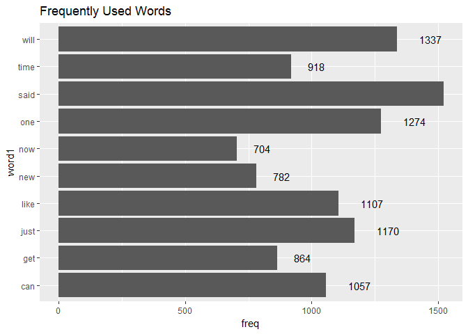

```r
g1 <- ggplot(data=unigram[1:10,], aes(x = word1, y = freq))
g2 <- g1 + geom_bar(stat="identity") + coord_flip() + ggtitle("Frequently Used Words")
g3 <- g2 + geom_text(data = unigram[1:10,], aes(x = word1, y = freq, label = freq), hjust=-1, position = "identity")
g3
```

## Obtaining biGrams

```r
# Tokenizer function to get bigrams
bigram <- NGramTokenizer(finalCorpus, Weka_control(min = 2, max = 2,delimiters = " \\r\\n\\t.,;:\"()?!"))
bigram <- data.frame(table(bigram))
bigram <- bigram[order(bigram$Freq,decreasing = TRUE),]
names(bigram) <- c("words","freq")
head(bigram)
```

```
##             words freq
## 126864   new york   92
## 102977  last year   76
## 158746  right now   65
## 102966  last week   63
## 215451  years ago   62
## 68758  first time   61
```

```r
bigram$words <- as.character(bigram$words)
str2 <- strsplit(bigram$words,split=" ")
bigram <- transform(bigram,
                    one = sapply(str2,"[[",1),
                    two = sapply(str2,"[[",2))
bigram <- data.frame(word1 = bigram$one,word2 = bigram$two,freq = bigram$freq,stringsAsFactors=FALSE)

## saving files
write.csv(bigram[bigram$freq > 1,],"bigram.csv",row.names=F)
```

## Obtaining triGrams

```r
# Tokenizer function to get trigrams
trigram <- NGramTokenizer(finalCorpus, Weka_control(min = 3, max = 3,delimiters = " \\r\\n\\t.,;:\"()?!"))
trigram <- data.frame(table(trigram))
trigram <- trigram[order(trigram$Freq,decreasing = TRUE),]
names(trigram) <- c("words","freq")
head(trigram)
```

```
##                         words freq
## 32097           cant wait see   14
## 141291         new york times   13
## 141241          new york city   11
## 162957 president barack obama   11
## 117061            let us know    8
## 88164      gov chris christie    7
```

```r
#####################
trigram$words <- as.character(trigram$words)
str3 <- strsplit(trigram$words,split=" ")
trigram <- transform(trigram,
                     one = sapply(str3,"[[",1),
                     two = sapply(str3,"[[",2),
                     three = sapply(str3,"[[",3))
# trigram$words <- NULL
trigram <- data.frame(word1 = trigram$one,word2 = trigram$two,
                      word3 = trigram$three, freq = trigram$freq,stringsAsFactors=FALSE)
# saving files
write.csv(trigram[trigram$freq > 1,],"trigram.csv",row.names=F)
```

## Obtaining quadGrams

```r
# Tokenizer function to get quadgrams
quadgram <- NGramTokenizer(finalCorpus, Weka_control(min = 4, max = 4,delimiters = " \\r\\n\\t.,;:\"()?!"))
quadgram <- data.frame(table(quadgram))
quadgram <- quadgram[order(quadgram$Freq,decreasing = TRUE),]

names(quadgram) <- c("words","freq")
quadgram$words <- as.character(quadgram$words)

str4 <- strsplit(quadgram$words,split=" ")
quadgram <- transform(quadgram,
                      one = sapply(str4,"[[",1),
                      two = sapply(str4,"[[",2),
                      three = sapply(str4,"[[",3),
                      four = sapply(str4,"[[",4))
# quadgram$words <- NULL
quadgram <- data.frame(word1 = quadgram$one,
                       word2 = quadgram$two,
                       word3 = quadgram$three,
                       word4 = quadgram$four,
                       freq = quadgram$freq, stringsAsFactors=FALSE)
# saving files
write.csv(quadgram[quadgram$freq > 1,],"quadgram.csv",row.names=F)
```

# Next Steps

## Considerations

```
- All the process from reading the file, cleaning and creating the n-grams is time-consuming for your computer.

- NLP uses intensive computer resource and is necessary a lot of tests get n-grams efficient keeping minimum files sizes.

- The techniques of removing words (cleaning) sometimes is not precise as we can suppose.

- Increasing the quality of n-gram tokenization could be critical to prediction accuracy at the prediction algorithm.
```

## Next Steps

```
- Build a Shiny app to allow the user input the word to obtain a suggestion of the next word.

- Develop the prediction algorithm implemented in Shiny app.

- Prepare a pitch about the app and publish it at "shinyapps.io" server.
```